# Final Assignment

Pekka Vartiainen

17.12.2017

# Abstract

High standard of living in a country doesn’t mean gender equality. The aim of this excercise is to identify a factor that measures female empowerment and to analyze, how countries’ welfare is related to the female empowerment. We use the UN dataset created for calculating HDI, human development index and GII, gender inequality index.

# Introduction

## About the data

We’ll be working with the ‘human’ dataset. It’s United Nations data, that aims for creating an index describing development of a country, that takes into account many different factors, not only e.g. economic development.

Two indices are calculated. One is called ‘HDI’, human development index. HDI is a mean of three indices - education index, life expectancy index, and GNI index (gross national income).

The other is called gender inequality index, ‘GII’, that reflects the differences between males and females. To give a general description, it is calculated based on level of female reproductive health, ratio of females vs males in work force, ratio of females vs. males with high education and ratio of females in parliament.

More accurate description of indices can be found [here](http://hdr.undp.org/sites/default/files/hdr2015_technical_notes.pdf)

### Data creation and variables

The data contains following variables: * edu_ratio: Ratio of females with at least secondary education to males with at least secondary education * part_ratio: ratio of females to males who are in the active labour force * edu_exp: expected years of education * life_exp: life expectancy * gni: gross national income * mat_mort_ratio: maternal mortality ratio * ado_birthr: adolescent birth rate * parli_f: percentage of female representatives in parliament

## Research question

*What describes female empowerment? What factors contribute to female empowerment?*

Female empowerment, i.e. the possibilities of women to participate in society, reflects IMO quite high human development. It would reflect that a society has gone beyond minimizing mortality and suffering. Having high human development index, in other words high education, life expectancy and GNI, doesn’t necessarily mean that females have equal chances to participate in society

1. From previous excercises, we’ve seen that edu_ratio, part_ratio and parli_f do not correlate that much, and not even with GII, gender equality index, although they are used to construct the index. With principal component analysis (PCA), can we find scales from the components of gender inequality index that represent possibilities of females in society? To put it more clearly, maternal mortality doesn’t necessarily tell a lot about women’s position in society especially in rich countries.
2. If we find this kind of scale, what components of societal development are most beneficial to gender equality? With linear regression, we can try to find components of human development index (gni, mean years of education, life expectancy) that could be related to women’s position. Does education help women to be empowered?

# Results

## Data characteristics

The structure of data and summary of variables:

```r
human <- read.csv("/Users/pecsi_max/Documents/GitHub/IODS-final/human", row.names = 1)
str(human)
```

```
## 'data.frame':    155 obs. of  10 variables:
##  $ edu_ratio     : num  1.007 0.997 0.983 0.989 0.969 ...
##  $ part_ratio    : num  0.891 0.819 0.825 0.884 0.829 ...
##  $ edu_mean      : num  12.6 13 12.8 12.7 11.9 13.1 12.2 12.9 13 12.5 ...
##  $ life_exp      : num  81.6 82.4 83 80.2 81.6 80.9 80.9 79.1 82 81.8 ...
##  $ gni           : int  64992 42261 56431 44025 45435 43919 39568 52947 42155 32689 ...
##  $ mat_mort_ratio: int  4 6 6 5 6 7 9 28 11 8 ...
##  $ ado_birthr    : num  7.8 12.1 1.9 5.1 6.2 3.8 8.2 31 14.5 25.3 ...
##  $ parli_f       : num  39.6 30.5 28.5 38 36.9 36.9 19.9 19.4 28.2 31.4 ...
##  $ hdi           : num  0.944 0.935 0.93 0.923 0.922 0.916 0.916 0.915 0.913 0.913 ...
##  $ gii           : num  0.067 0.11 0.028 0.048 0.062 0.041 0.113 0.28 0.129 0.157 ...
```

```r
summary(human)
```

```
##    edu_ratio        part_ratio        edu_mean         life_exp
##  Min.   :0.1717   Min.   :0.1857   Min.   : 1.400   Min.   :49.00
##  1st Qu.:0.7264   1st Qu.:0.5984   1st Qu.: 6.000   1st Qu.:66.30
##  Median :0.9375   Median :0.7535   Median : 8.500   Median :74.20
##  Mean   :0.8529   Mean   :0.7074   Mean   : 8.302   Mean   :71.65
##  3rd Qu.:0.9968   3rd Qu.:0.8535   3rd Qu.:10.900   3rd Qu.:77.25
##  Max.   :1.4967   Max.   :1.0380   Max.   :13.100   Max.   :83.50
##       gni         mat_mort_ratio     ado_birthr        parli_f
##  Min.   :   581   Min.   :   1.0   Min.   :  0.60   Min.   : 0.00
##  1st Qu.:  4198   1st Qu.:  11.5   1st Qu.: 12.65   1st Qu.:12.40
##  Median : 12040   Median :  49.0   Median : 33.60   Median :19.30
##  Mean   : 17628   Mean   : 149.1   Mean   : 47.16   Mean   :20.91
##  3rd Qu.: 24512   3rd Qu.: 190.0   3rd Qu.: 71.95   3rd Qu.:27.95
##  Max.   :123124   Max.   :1100.0   Max.   :204.80   Max.   :57.50
##       hdi              gii
##  Min.   :0.3480   Min.   :0.0160
##  1st Qu.:0.5925   1st Qu.:0.1840
##  Median :0.7330   Median :0.3850
##  Mean   :0.7039   Mean   :0.3659
##  3rd Qu.:0.8290   3rd Qu.:0.5245
##  Max.   :0.9440   Max.   :0.7440
```

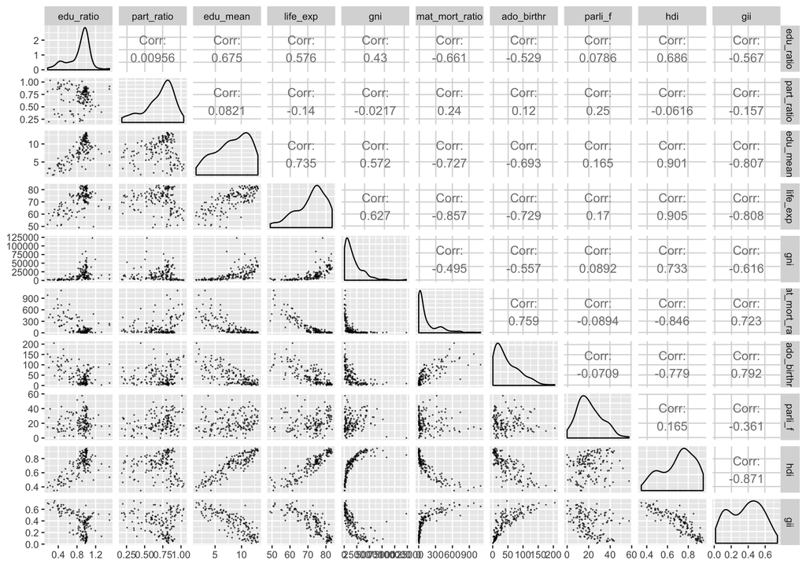

```r
# exploratory graph showing correlations
pairs_plot_human <- ggpairs(human, mapping = aes(alpha = 0.5),
                      lower = list(combo = wrap("facethist", bins = 20),
                                   continuous = wrap("points", size=0.1)),
                      upper = list(continuous = wrap("cor", alpha = 1)))
pairs_plot_human
```

### Logaritmic transformation for distributions

Let’s do a logarithmic transformation for variables ado_birthr, gni, and mat_mort_ratio. PCA and other statistical analyses assume normal distribution, and the log-transformed variables should work better in the analyses.

```r
human_log <- human %>%
  dplyr::mutate(ado_birthr = log(ado_birthr),
                gni = log(gni),
                mat_mort_ratio = log(mat_mort_ratio)) %>%
  dplyr::rename(ado_birth_log = ado_birthr,
                gni_log = gni,
                mat_mort_log = mat_mort_ratio)
```

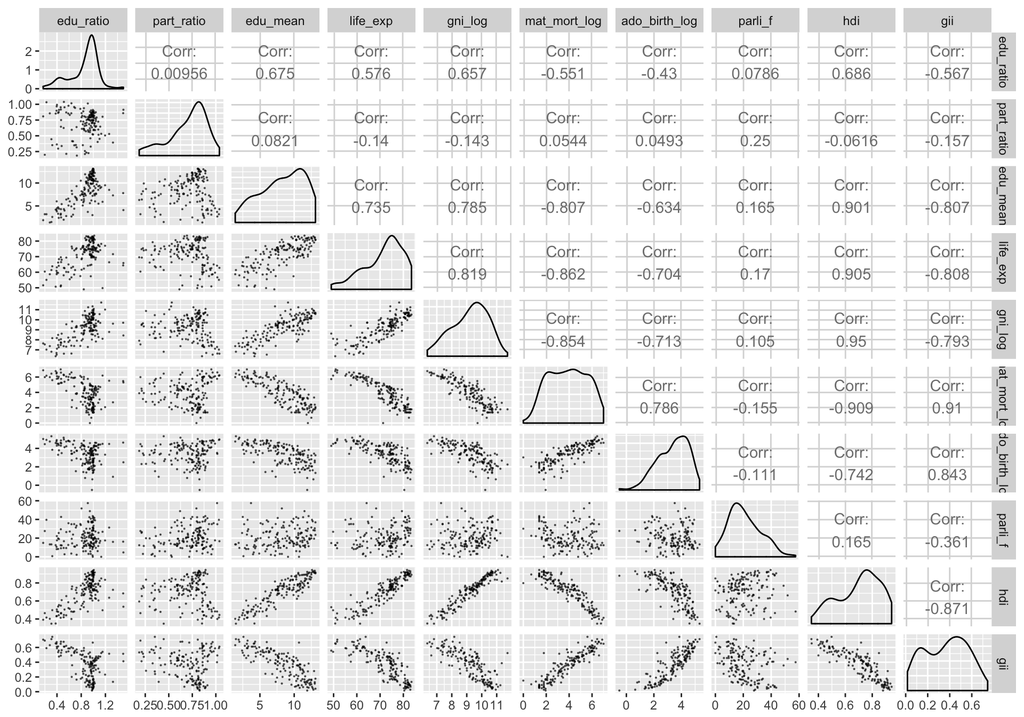

```r
#for some reason, the mutation above dropped the row names. Let's set them again from the original data.
rownames(human_log) <- rownames(human)

pairs_plot_human_log <- ggpairs(human_log, mapping = aes(alpha = 0.5),
                      lower = list(combo = wrap("facethist", bins = 20),
                                   continuous = wrap("points", size=0.1)),
                      upper = list(continuous = wrap("cor", alpha = 1)))

pairs_plot_human_log
```

The distributions of log-transformed variables. They look much better now.

## Principal component analysis

For the PCA, we use the gender inequality variables separately. This might reasonable, because they are not that much correlated in the previous pairs plots.

```r
# select the variables from log-transformed dataset and scale
human_pca <- human_log %>%
  dplyr::select(parli_f, edu_ratio, part_ratio, ado_birth_log, mat_mort_log) %>%
  scale

pca_human <- prcomp(human_pca)
summary(pca_human)
```

```
## Importance of components:
##                          PC1    PC2    PC3    PC4     PC5
## Standard deviation     1.492 1.1138 0.8622 0.7706 0.44392
## Proportion of Variance 0.445 0.2481 0.1487 0.1188 0.03941
## Cumulative Proportion  0.445 0.6932 0.8418 0.9606 1.00000
```

The first component explains 45% of the variance in the variables, and the second 25%. Let’s look at the biplot of the first 2 PC:s.

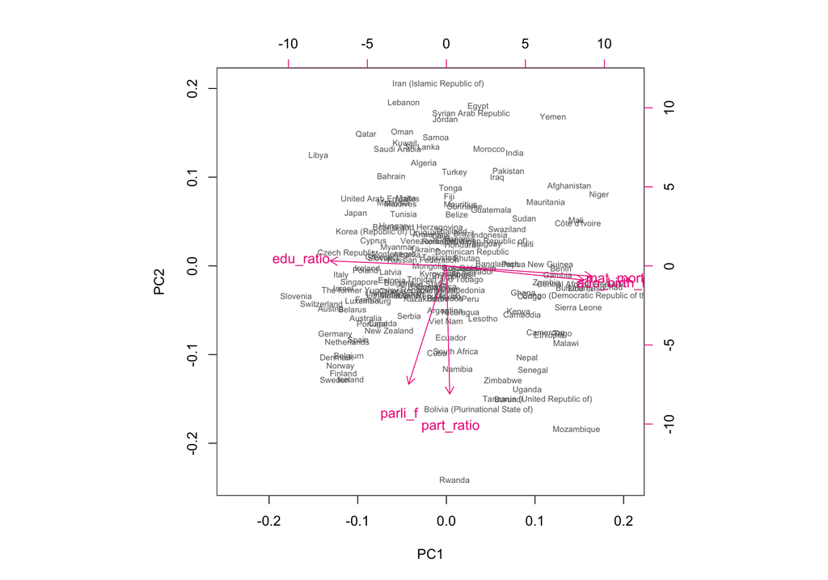

```r
biplot(pca_human, choices = 1:2, cex = c(0.6, 1), col = c("grey40", "deeppink2"))
```

The two first components, PC1 and PC2 are quite nicely aligned. Edu_ratio, maternal mortality and adolescent birthrate contribute mainly to the first PC, and parli_f and part_ratio contribute to PC2. We can deduct that the PC2 would somehow reflect the women’s position in society, while PC1 describes the so-called minimum requirements for women’s welfare.

Note that the Nordic countries are nicely separated in low left, and belgium is with them.

There are some pretty evident outliers as well. We might have a good reason to doubt that Rwanda might have some problems in providing reliable data.

## Linear regression

### What predicts female participation?

We do a linear regression model predicting the PC2 from previous analyses. First, we add the PC2 to the dataset.

```r
# extract the two first principal components by using 'predict',
comps <- predict(pca_human) %>% as.data.frame %>% dplyr::select(PC1, PC2)
#add the columns to dataframe
human_comp <- merge(human_log, comps, by = "row.names")
# Merge adds row names as a new variable, so we need to add names and drop the old variable
rownames(human_comp) <- human_comp$Row.names
human_comp <- human_comp %>% dplyr::select(-Row.names)


head(dplyr::select(human_comp, PC2), 10)
```

```
##                    PC2
## Afghanistan  1.2444951
## Albania      0.1805624
## Algeria      1.6035640
## Argentina   -0.7034420
## Armenia      0.4973912
## Australia   -0.8158768
## Austria     -0.6643588
## Azerbaijan  -0.3959963
## Bahamas     -0.3293504
## Bahrain      1.4033097
```

Here we have a scale trying to represent the possibilities of females in participating to society. Note that smaller or negative values reflect “better” participation of women.

Next, we select variables to be used in the linear model, and we look at their associations with one last pairs plot.

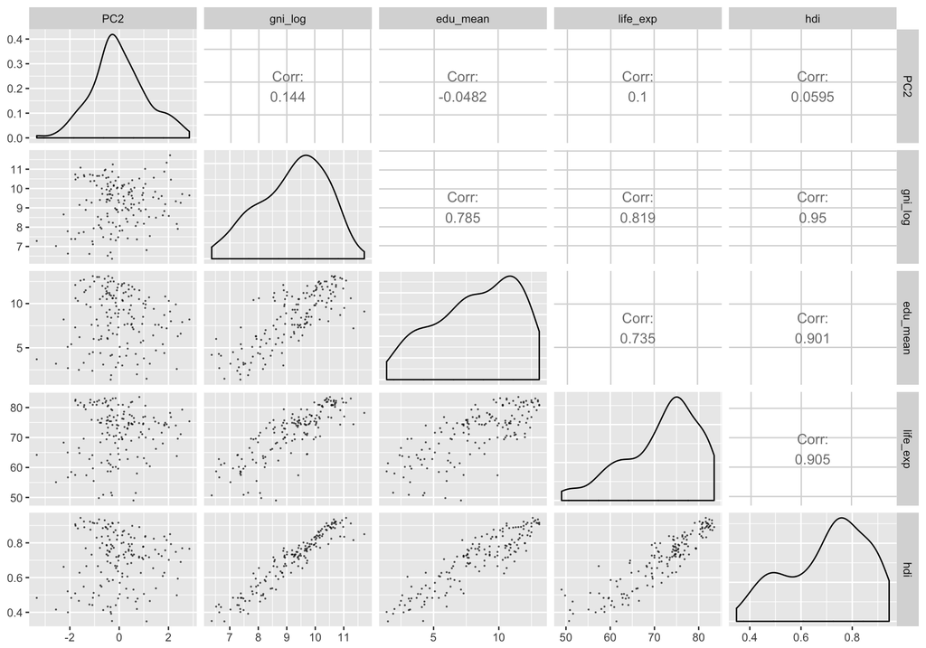

```r
human_reg <- human_comp %>% dplyr::select(PC2, gni_log, edu_mean, life_exp, hdi)

ggpairs(human_reg, mapping = aes(alpha = 0.5),
                      lower = list(combo = wrap("facethist", bins = 20),
                                   continuous = wrap("points", size=0.1)),
                      upper = list(continuous = wrap("cor", alpha = 1)))
```

We see that PC2 is not really correlated with any of the variables. Not a surprise, when we remember how GNI, life expectancy and edu_mean were correlated with maternal mortality but not with parli_f and part_ratio. GNI, edu_mean and life_exp are very strongly correlated. Let’s still try to create an exploratory linear model, to see if things change when the effect of other variables is held constant.

```r
lm <- lm(data = human_reg, PC2 ~ gni_log + edu_mean + life_exp)

summary(lm)
```

```
##
## Call:
## lm(formula = PC2 ~ gni_log + edu_mean + life_exp, data = human_reg)
##
## Residuals:
##     Min      1Q  Median      3Q     Max
## -3.2070 -0.6956  0.0042  0.6441  2.6196
##
## Coefficients:
##              Estimate Std. Error t value Pr(>|t|)
## (Intercept) -3.097781   0.959855  -3.227 0.001533 **
## gni_log      0.406662   0.144621   2.812 0.005579 **
## edu_mean    -0.154820   0.046037  -3.363 0.000977 ***
## life_exp     0.008925   0.018738   0.476 0.634562
## ---
## Signif. codes:  0 '***' 0.001 '**' 0.01 '*' 0.05 '.' 0.1 ' ' 1
##
## Residual standard error: 1.073 on 151 degrees of freedom
## Multiple R-squared:  0.08984,    Adjusted R-squared:  0.07176
## F-statistic: 4.968 on 3 and 151 DF,  p-value: 0.002571
```

Now GNI and mean years of education appear as statistically significant predictors.

However, the R2 of the model is very small, indicating that there’s a lot of unexplained variance. Another problem is that edu_mean is very strongly correlated with GNI and life expectancy, which might present a problem with collinearity. Collinearity is not analyzed here.

Still, the results suggest that education might have some role in female empowerment. Interestingly GNI and education have opposite associations with PC2, when they are in the same model. This makes sense, because PC2 was constructed so that it would not be too much related to HDI, where GNI is an important component (see the ‘PCA’ section).

### model diagnostics

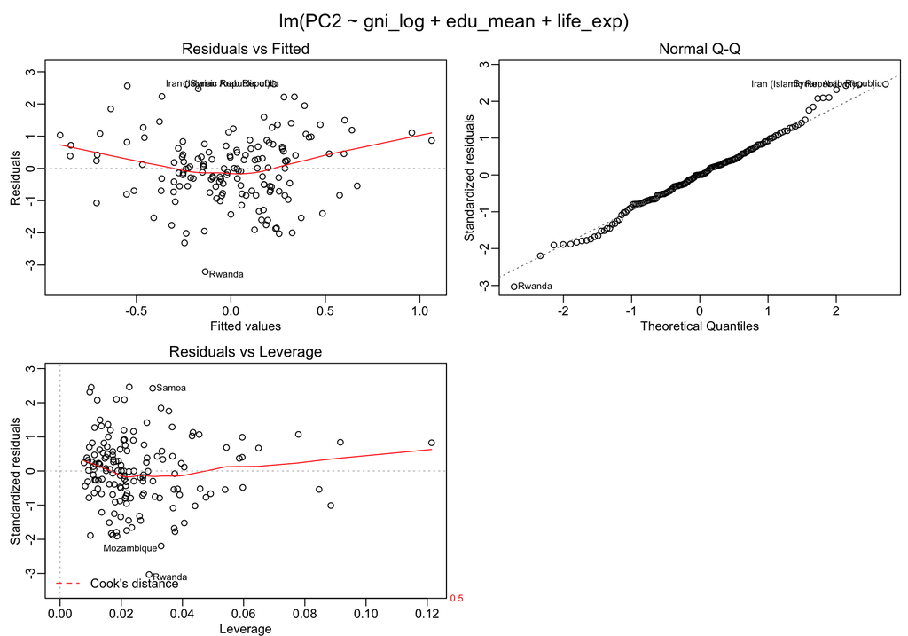

```r
par(mfrow = c(2,2), oma = c(0, 0, 2, 0), mar = c(2.5,3,2,0.5), mgp = c(1.5,.5,0))
plot(lm, which = c(1,2,5), add.smooth = T)
```

#### about the diagnostic plots

- in ‘Residuals’, the mean of residuals (i.e. the difference between predicted and observed values of ‘points’) is close to zero, but in the extreme ends it appears to rise above zero, reminding of parabolar shape.
- in ‘Normal Q-Q’ plot, most of the residuals are beautifully lined, except for extreme ends. Same outliers are indicated - Rwanda again, and also some middle Eastern countries.
- in ‘Residuals vs. Leverage’, all the cases are well inside the Cook’s distance, which means that even the outliers follow the pattern of other data points, and that they should not change the model too much. In fact, the limit values of Cook’s distance fall outside of the plot’s range.

### summary of the linear model

In summary, the model’s not good for describing a phenomenom, but it hints that there might be an association.

When GNI is held constant, mean years of education appear to be associated with slightly better females’ participation in societal activities.

## Ideas for further research

Next, we could limit this type of analysis to only a set of similar countries, for example based on GDP or geographical locations.

Some non-linear approaches could help to clarify these results. Obviously, these phenomena are not necessarily linear in nature.

Also K-means clustering or some other clustering technique might be beneficial for identifying groups of countries that fare similarly in these measurements. Further, it could be interesting to see if e.g. some western European countries do clearly better or worse in females’ participation in society.

# Thanks for reading!

What follows is for my own exploration, no need to read or include to the assessment!